# Text Mining: Extración de información de documentos PDF

by [María Luisa Duque](https://www.linkedin.com/in/marialuisaduque/)

2020-06-05

## Extraer información de documentos con formato pdf

El objetivo de la presente tarea consiste en acceder a un web, descargar un pdf y hacer un análisis de texto sobre tal documento.

El documento objetivo es el Real Decreto 463/2020, del 14 de marzo, publicado en el Boletín Oficial del Estado (BOE) por el que se declara el Estado de Alarma para la gestión de la situación de crisis sanitaria ocasionada por el COVID-19.

Vamos a obtener el documento a través de la website del Boletín Oficial del Estado [BOE](https://www.boe.es/).

Descargamos el documento:

```r
download.file('https://www.boe.es/boe/dias/2020/03/14/pdfs/BOE-A-2020-3692.pdf', 'RD463_2020.pdf', mode="wb")
```

El documento descargado lo podemos ver en el directorio de trabajo (RD_463/2020.pdf)

```r
list.files()
```

[output not shown]

### Análisis de documento

Usamos la librería **tm** para leer directamente el pdf con la función **readPDF**.

```r
# Cargamos librerías
library(tm)
library(dplyr)
```

```r
library(tidyr)
library(tm)
library(wordcloud)
library(ggplot2)
# Nombre del archivo
filename = "RD463_2020.pdf"

# Lectura del archivo pdf
pdf_doc <- readPDF(control=list(text='-enc "UTF-8"'))(elem = list(uri = filename),
                                                  language="es")
```

Analizamos el objeto pdf.

La clase:

```r
class(pdf_doc)
```

```
## [1] "PlainTextDocument" "TextDocument"
```

Las variables:

```r
names(pdf_doc)
```

```
## [1] "content" "meta"
```

Los metadatos:

```r
pdf_doc$meta
```

```
##   author       : MINISTERIO DE LA PRESIDENCIA, RELACIONES CON LAS CORTES Y MEMORIA DEMOCRÁTICA
##   datetimestamp: 2020-03-14 23:38:38
##   description  : BOE-A-2020-3692
##   heading      : Disposición 3692 del BOE núm. 67 de 2020
##   id           : RD463_2020.pdf
##   language     : es
##   origin       : eBOE
```

Las tres primeras líneas:

```r
head(pdf_doc$content, 3)
```

```
## [1] "                        BOLETÍN OFICIAL DEL ESTADO\r\nNúm. 67                                   Sábado 14 de marzo de 2020                            Sec. I. Pág. 25390\r\n                               I. DISPOSICIONES GENERALES\r\n                        MINISTERIO DE LA PRESIDENCIA,\r\n  …
## [2] "                        BOLETÍN OFICIAL DEL ESTADO\r\nNúm. 67                                  Sábado 14 de marzo de 2020                                 Sec. I. Pág. 25391\r\n          Artículo 3.   Duración.\r\n              La duración del estado de alarma que se declara por el presente r…
## [3] "                        BOLETÍN OFICIAL DEL ESTADO\r\nNúm. 67                                 Sábado 14 de marzo de 2020                               Sec. I. Pág. 25392\r\n              5. El Ministro del Interior podrá dictar las órdenes, resoluciones, disposiciones e\r\n          instrucc…
```

La longitud del texto:

```r
length(pdf_doc$content)
```

```
## [1] 11
```

El contenido, como un conjunto de lineas de texto, se extrae con la función **content()**. En las lineas aparecen caracteres especiales, muchas en blanco y otros elementos que sera necesario filtrar como parte del procesamiento.

Extraemos el texto, pasando de un objeto “PlainTextDocument” a un objeto “character”.

```r
pdf_texto <- content(pdf_doc)
```

Examinamos el objeto **pdf_texto**.

```r
str(pdf_texto)
```

```
##  chr [1:11] "                        BOLETÍN OFICIAL DEL ESTADO\r\nNúm. 67                                   Sábado 14 de ma"| __truncated__ ...
```

### ETL: Extract, Transform and Load

Realizamos un procedimiento de ETL sobre nuestro objeto.

Eliminamos las líneas vacías:

```r
pdf_texto <- pdf_texto[pdf_texto != ""]
str(pdf_texto)
```

```
##  chr [1:11] "                        BOLETÍN OFICIAL DEL ESTADO\r\nNúm. 67                                   Sábado 14 de ma"| __truncated__ ...
```

No parece que existan caracteres especiales en nuestro texto.

Podríamos los números con la función **gsub**; sin embargo, al tratarse de un texto del BOE consideramos que los números es mejor mantenerlos ya que pueden ser fechas o datos de importancia numérica contextual.

```r
#pdf_texto <- gsub("[0-9]*", "", pdf_texto)
#str(pdf_texto)
```

Convertimos todas las mayúsculas en minúsculas:

```r
pdf_texto <- gsub(pattern = '([[:upper:]])', perl = TRUE, replacement = '\\L\\1', pdf_texto)
```

Eliminamos las comas:

```r
pdf_texto <- gsub(",", "", pdf_texto)
```

También se podría hacer, de una forma más rápida, definiendo una función como la siguiente:

```r
# Defino una funcion para ir filtrando texto
clean.text <- function(x= "Texto Nulo"){
  x <- gsub("(<[^>]*>)", "", x)             # Quitamos el codigo html de los links
  x <- gsub("(\n)", "", x)                  # Quitamos los saltos de linea \n
  x <- gsub("(&#[0-9]*;)", "", x)           # Quitamos simbolos de puntuacion,superindices, etc
}
```

Definimos una función para eliminar los acentos:

```r
acentos.text <- function(x="Texto Nulo"){
  # Quito todos los acento para tener menos dificultades con la nube de palabras
  # Cambio la ñ porque de problemas en la nube
  x <- gsub("á", "a", x)
  x <- gsub("é", "e", x)
  x <- gsub("í", "i", x)
  x <- gsub("ó", "o", x)
  x <- gsub("ú", "u", x)
  x <- gsub("ñ", "n", x)
}
```

Aplicamos nuestra flución sobre pdf_texto.

```r
pdf_texto <- clean.text(pdf_texto)
pdf_texto <- acentos.text(pdf_texto)
```

Ahora podemos buscar dentro del texto usando la función **grep**, por ejemplo la palabra alamar o covid.

```r
index_alarma <- grep("\\Walarma\\W", pdf_texto, ignore.case = TRUE, perl = TRUE)
head(pdf_texto[index_alarma], 3) # Solo los tres primeros
```

```
## [1] "                        boletÍn oficial del estado\rnum. 67                                   sabado 14 de marzo de 2020                            sec. i. pag. 25390\r                               i. disposiciones generales\r                        ministerio de la presidencia\r           …
## [2] "                        boletÍn oficial del estado\rnum. 67                                  sabado 14 de marzo de 2020                                 sec. i. pag. 25391\r          articulo 3.   duracion.\r              la duracion del estado de alarma que se declara por el presente real de…
## [3] "                        boletÍn oficial del estado\rnum. 67                                 sabado 14 de marzo de 2020                               sec. i. pag. 25392\r              5. el ministro del interior podra dictar las ordenes resoluciones disposiciones e\r          instrucciones qu…
```

Hemos creado un objeto, index_alarma, que apunta a las líneas donde aparece la palabra alarma.

```r
index_alarma # Apunta a los elementos en los que aparece la palabra alarma
```

```
## [1] 1 2 3 8 9
```

Busquemos en qué elementos aparece la palabra covid.

```r
index_covid <- grep("\\Wcovid\\W", pdf_texto, ignore.case = TRUE, perl = TRUE)
index_covid # Apunta a los elementos en los que aparece la palabra covid
```

```
## [1] 1 9
```

### Corpus

Es necesario crear un corpus de **tm** para poder lematizar y realizar otras operaciones de minería de texto, para ello usamos la función **Corpus**:

```r
corpus <- Corpus(VectorSource(pdf_texto), readerControl = list(language = "es"))
corpus
```

```
## <<SimpleCorpus>>
## Metadata:  corpus specific: 1, document level (indexed): 0
## Content:  documents: 11
```

Quitamos los espacios en blanco:

```r
corpus <- tm_map(corpus, stripWhitespace)
```

Quitamos las stopwords en español:

```r
corpus <- tm_map(corpus, removeWords, stopwords('es'))
```

Quitamos el resto de signos de puntuación que queden, con la opción **removePuntuation**:

```r
corpus <- tm_map(corpus, removePunctuation)
```

Quitamos la preposición ‘tras’ no incluida como stopword:

```r
corpus <- tm_map(corpus, removeWords, "tras")
```

### Nube de palabras: WordCloud

```r
library(wordcloud)
```

Nos quedamos con las palabras que aparecen, al menos 10 veces.

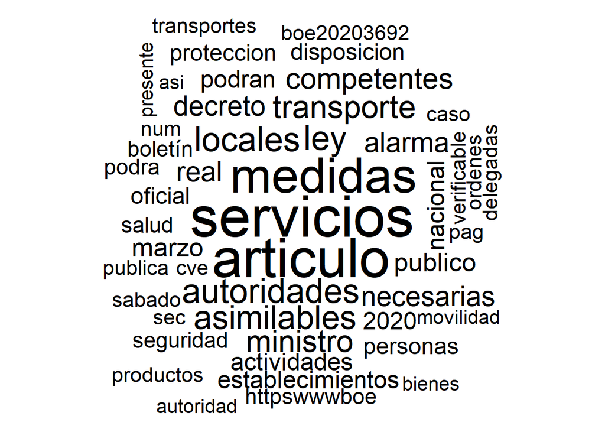

```r
wordcloud(corpus, min.freq = 10, random.order = FALSE)
```

Parece que la salida es óptima y satisfactoria.

### Matriz DTM (Documen Term Matrix)

Ahora vamos a crear una matriz DTM (document-term matrix). Básicamente son matrices en las que se representan los términos que aparecen en un determinado documento y con qué frecuencia.

Por otro lado, encontramos también las TDM (term-document matrix), que a diferencia de la anteriores, se usan para buscar en qué documentos aparece un determinado término

```r
pdf_dtm <- DocumentTermMatrix(corpus)
pdf_dtm
```

```
## <<DocumentTermMatrix (documents: 11, terms: 1134)>>
## Non-/sparse entries: 1976/10498
## Sparsity           : 84%
## Maximal term length: 25
## Weighting          : term frequency (tf)
```

Las variables del objeto **pdf_dtm**.

```r
names(pdf_dtm)
```

```
## [1] "i"        "j"        "v"        "nrow"     "ncol"     "dimnames"
```

Las dimensiones:

```r
pdf_dtm$nrow
```

```
## [1] 11
```

```r
pdf_dtm$ncol
```

```
## [1] 1134
```

### Palabras frecuentes: Wordcloud, matrices DTM y TMD

La lista de términos con una frecuencia mínima de 10. En esta ocasión vamos a usar la función **findFreqTerms** del paquete **tm**.

```r
findFreqTerms(pdf_dtm, 10)
```

```
##  [1] "2020"             "alarma"           "articulo"         "boe20203692"
##  [5] "boletín"          "cve"              "decreto"          "httpswwwboe"
##  [9] "ley"              "marzo"            "medidas"          "ministro"
## [13] "movilidad"        "nacional"         "num"              "oficial"
## [17] "pag"              "presente"         "publica"          "real"
## [21] "sabado"           "salud"            "sec"              "seguridad"
## [25] "transportes"      "verificable"      "actividades"      "autoridad"
## [29] "autoridades"      "bienes"           "caso"             "competentes"
## [33] "delegadas"        "disposicion"      "establecimientos" "locales"
## [37] "necesarias"       "ordenes"          "personas"         "podran"
## [41] "proteccion"       "servicios"        "podra"            "productos"
## [45] "publico"          "asi"              "transporte"       "asimilables"
```

También podríamos quitar los números con **tm_map** haciendo uso de corpus del siguiente modo, como hemos mencionado anteriormente, los datos numéricos nos pueden resultar significativos en importancia dado el carácter documento aquí tratado; sin embargo, vamos a optar por eliminarlos ahora.

```r
corpus_clean <- tm_map(corpus, removeNumbers)
```

Inspeccinamos:

```r
inspect(corpus[1:3])
```

```
## <<SimpleCorpus>>
## Metadata:  corpus specific: 1, document level (indexed): 0
## Content:  documents: 3
##
## [1]  boletÍn oficial   num 67 sabado 14  marzo  2020 sec i pag 25390 i disposiciones generales ministerio   presidencia relaciones   cortes  memoria democrÁtica 3692 real decreto 4632020  14  marzo     declara    alarma   gestion   situacion  crisis sanitaria ocasionada   covid19  organizacion mu…
## [2]  boletÍn oficial   num 67 sabado 14  marzo  2020 sec i pag 25391 articulo 3 duracion  duracion    alarma   declara   presente real decreto   quince dias naturales articulo 4 autoridad competente 1   efectos    alarma  autoridad competente sera  gobierno 2   ejercicio   funciones    hace refer…
## [3]  boletÍn oficial   num 67 sabado 14  marzo  2020 sec i pag 25392 5  ministro  interior podra dictar  ordenes resoluciones disposiciones  instrucciones  considere necesarias    sujetos incluidos   ambito  aplicacion   ley 52014  4  abril  seguridad privada 6   eficaz cumplimiento   medidas inc…
```

Ahora construimos un DTM con los textos tratados, **pdf_dtm_clean**.

```r
pdf_dtm_clean <- DocumentTermMatrix(corpus_clean)
pdf_dtm_clean
```

```
## <<DocumentTermMatrix (documents: 11, terms: 1096)>>
## Non-/sparse entries: 1921/10135
## Sparsity           : 84%
## Maximal term length: 25
## Weighting          : term frequency (tf)
```

La lista de términos con una frecuencia mínima de 10.

```r
findFreqTerms(pdf_dtm_clean, 10)
```

```
##  [1] "alarma"           "articulo"         "boe"              "boletín"
##  [5] "cve"              "decreto"          "httpswwwboe"      "ley"
##  [9] "marzo"            "medidas"          "ministro"         "movilidad"
## [13] "nacional"         "num"              "oficial"          "pag"
## [17] "presente"         "publica"          "real"             "sabado"
## [21] "salud"            "sec"              "seguridad"        "transportes"
## [25] "verificable"      "actividades"      "autoridad"        "autoridades"
## [29] "bienes"           "caso"             "competentes"      "delegadas"
## [33] "disposicion"      "establecimientos" "locales"          "necesarias"
## [37] "ordenes"          "personas"         "podran"           "proteccion"
## [41] "servicios"        "podra"            "productos"        "publico"
## [45] "asi"              "transporte"       "asimilables"
```

Realizamos, de nuevo, el **wordcloud**.

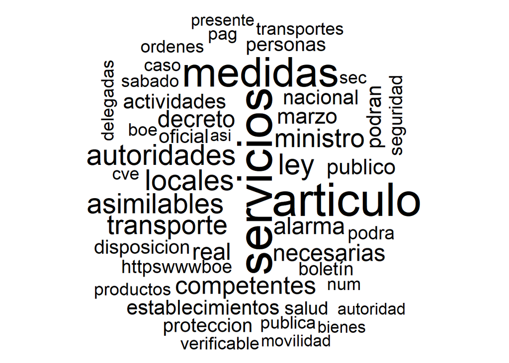

```r
wordcloud(corpus_clean, min.freq = 10, random.order = FALSE)
```

Realizamos la misma nube *wordcloud* pero en formato con colores.

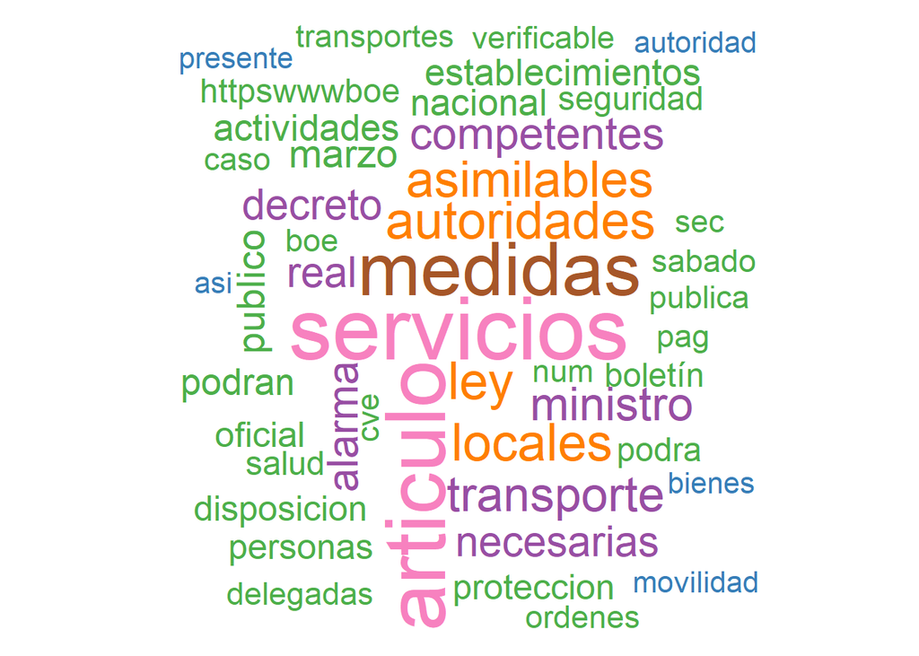

```r
# Nube de palabras
wordcloud(corpus_clean, min.freq = 10, random.order = FALSE,
          colors = brewer.pal(8, "Set1"))
```

Parece que aparte de **servicios**, **articulo** y **medidas** que parecen evidentes, tenemos **locales**, **ley**, **asimilables**, **autoridades**, palabras que podemos asociar con el RD aquí objeto de estudio.

Para ver mas cosas, creamos una matriz TDM.

```r
# Obtenemos el TDM
tdm <- TermDocumentMatrix(corpus_clean)

# Lo convertimos em matriz
t   <- as.matrix(tdm)

# Ordenamos la matriz
v   <- sort(t[, 1], decreasing = TRUE)

# Y creamos el objeto como dataframe
tdm_matriz  <- data.frame(word=names(v), freq=v)

head(tdm_matriz, 10)
##                    word freq
## alarma           alarma    8
## articulo       articulo    6
## situacion     situacion    5
## gobierno       gobierno    4
## marzo             marzo    4
## medidas         medidas    4
## salud             salud    4
## covid             covid    3
## crisis           crisis    3
## declaracion declaracion    3
```

Los términos mas frecuentes:

```r
# Encontramos los terminos con una frecuencia superior a 5
findFreqTerms(tdm, 5)
##   [1] "agenda"           "alarma"           "articulo"
##   [4] "boe"              "boletín"          "caracter"
##   [7] "crisis"           "cve"              "decreto"
##  [10] "derechos"         "disposiciones"    "dispuesto"
##  [13] "ejercicio"        "fin"              "gestion"
##  [16] "gobierno"         "httpswwwboe"      "interior"
##  [19] "junio"            "ley"              "marzo"
##  [22] "medidas"          "ministro"         "movilidad"
##  [25] "nacional"         "num"              "oficial"
##  [28] "organica"         "pag"              "presente"
##  [31] "previstas"        "primera"          "publica"
##  [34] "real"             "sabado"           "salud"
##  [37] "sanidad"          "sanitaria"        "sec"
##  [40] "seguridad"        "situacion"        "suspension"
##  [43] "territorio"       "transportes"      "urbana"
##  [46] "verificable"      "actividades"      "acuerdo"
##  [49] "adicional"        "anterior"         "aquellas"
##  [52] "asegurar"         "asimismo"         "autonomicas"
##  [55] "autoridad"        "autoridades"      "bienes"
##  [58] "caso"             "competente"       "competentes"
##  [61] "delegadas"        "dictar"           "disposicion"
##  [64] "efectos"          "establecimientos" "fuerzas"
##  [67] "garantizar"       "locales"          "lugares"
##  [70] "necesarias"       "necesario"        "necesarios"
##  [73] "oficio"           "ordenes"          "personas"
##  [76] "podran"           "prestacion"       "previsto"
##  [79] "procedimiento"    "proteccion"       "sera"
##  [82] "servicios"        "vehiculos"        "vigencia"
##  [85] "acordar"          "actividad"        "administraciones"
##  [88] "alimentos"        "ambito"           "centros"
##  [91] "circulacion"      "cualquier"        "materia"
##  [94] "necesidad"        "podra"            "privada"
##  [97] "productos"        "publico"          "sanitarios"
## [100] "servicio"         "siguientes"       "asi"
## [103] "esenciales"       "operadores"       "publicas"
## [106] "relacion"         "suspenden"        "terminos"
## [109] "abastecimiento"   "condiciones"      "establecer"
## [112] "ferroviarios"     "medios"           "resolucion"
## [115] "sector"           "sometidos"        "titularidad"
## [118] "transporte"       "viajeros"         "actuaciones"
## [121] "plazos"           "asimilables"      "instalaciones"
## [124] "recintos"         "salas"            "salones"
## [127] "bares"
```

Visualización gráfica, gráfico de barras:

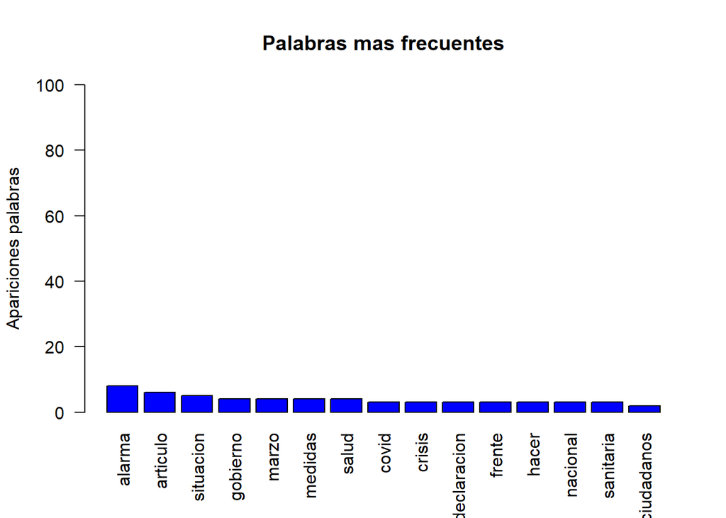

```r
library(RColorBrewer)
coul <- brewer.pal(5, "Set2")

# Creamos un grafico de barras y nos quedamos con los primeros 15 valores
barplot(tdm_matriz[1:15, ]$freq,               # Datos
        las       = 2,
        names.arg = tdm_matriz[1:15, ]$word,   # Texto en la x
        col       = "blue",                    # Color
        main      = "Palabras mas frecuentes", # Título
        ylab      = "Apariciones palabras",    # Texto en la y
        ylim =     c(0, 100))                  # Limitamos el eje y a [0, 100]
```

### Peso relativo de las palabras con mayor número de aparaciones

Preparamos los datos

```r
# Prepara los datos para unificar en suma las apariciones de palabras
# a partir de la 5º

# Creamos un objeto data frame
sect           <- data.frame()

# Las primera 10 filas de tdm_matriz, con dos variables word y freq
sect           <- tdm_matriz[1:4, ]

# Convertimos la variable word a caracter (es de tipo factor)
sect$word      <- as.character(sect$word)

# Obtenemos los nombres de las filas (los 10 términos mas usados)
filas          <- rownames(sect)

# Y creamos otro valor que agrupe todo lo que no entra en los 10 primeros
filas          <- c(filas, "Resto_palabras")

# Incluimos los valores para el elemento 11 en sect. Primero el word, sect[11, 1]
sect[5, 1]    <- "Resto_palabras"

# Por último el nombre de las filas
rownames(sect) <- filas
```

Generamos el gráfico

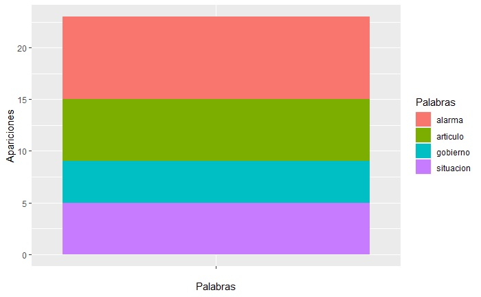

```r
# Y creo un grafico que llamo sector
sector <- ggplot(sect, aes(x = "", y = freq, fill = word)) +
  geom_bar(stat = "identity", width = 1) +
  labs(x = "Palabras", y = "Apariciones", fill = "Palabras")
sector
```

Consideramos que éste gráfico, sin bien es visualmente llamativo, no es más representativo que los anteriores.

### Diccionario

Ahora vamos a crear un diccionario con las palabras con un número mínimo de apariciones de 5.

```r
Dictionary <- function(x) {
  if( is.character(x) ) {
    return (x)
  }
  stop('x is not a character vector')
}
```

Aplicamos esa función (Dictionary) a un objeto que agrupe los términos que aparecen al menos 5 veces en pdf_dtm generando el objeto Hay que destacar que estamos usando pdf_dtm y no pdf_dtm_clean.

```r
pdf_dict  <- Dictionary(findFreqTerms(pdf_dtm, 5))
length(pdf_dict)
```

```
## [1] 129
```

Y en pdf_dtm_clean.

```r
pdf_dict_clean  <- Dictionary(findFreqTerms(pdf_dtm_clean, 5))
length(pdf_dict_clean)
```

```
## [1] 127
```

### Referencias y Comentarios

**Referencias**

Parte de este código ha sido recopilado de las lecciones del profesor [Santiago Mota](https://www.linkedin.com/in/santiagomota/), Master in Big Data and & Data Science at Complutense University of Madrid, que a su vez ha sido inspirado de la documentación [Join, split, and compress PDF files with pdftools](https://www.r-bloggers.com/join-split-and-compress-pdf-files-with-pdftools/).

**Comentarios**

El presente código ha sido ejecutado en el sistema operativo version Windows 10, 64 bits, escogiendo formato de codificación en RStudio UTF-8.

A work by [María Luisa Duque](https://www.linkedin.com/in/marialuisaduque/)

*marialdu@umc.es*